# XDPFlyModel

Minjue Wu

12/12/2019

### Modeling X-linked Dystonia Parkinsonism Via A Novel Fly Model

## A Preview: The Data Collection Process

This database contains four weeks/420 hours’ worth of fly model data, including target genes, sorter, weekday, number of surviving flies, phenotype, and sizes of the right and left eye of every mutant fly. I and 5 other classmates gathered the dataset from LS100 and cleaned it from scratch, as the datasheets used by the student researchers were completely unusable for code processing purposes, and often I had to pick up their scratch paper to get accurate data on eye sizes for every individual fly in the 18000+ dataset. A majority of the dataset had to be input by hand. Initially I abbreviated the numbers in each vial categorically, but realized it was not ideal for bar plots and scatterplots, so manually added correct number of replicate entries for all flies. Original data can be found [here](https://drive.google.com/open?id=1FQpT1aZWjhlm-Inn_hrF55AL-AXEOI7F) for reference.

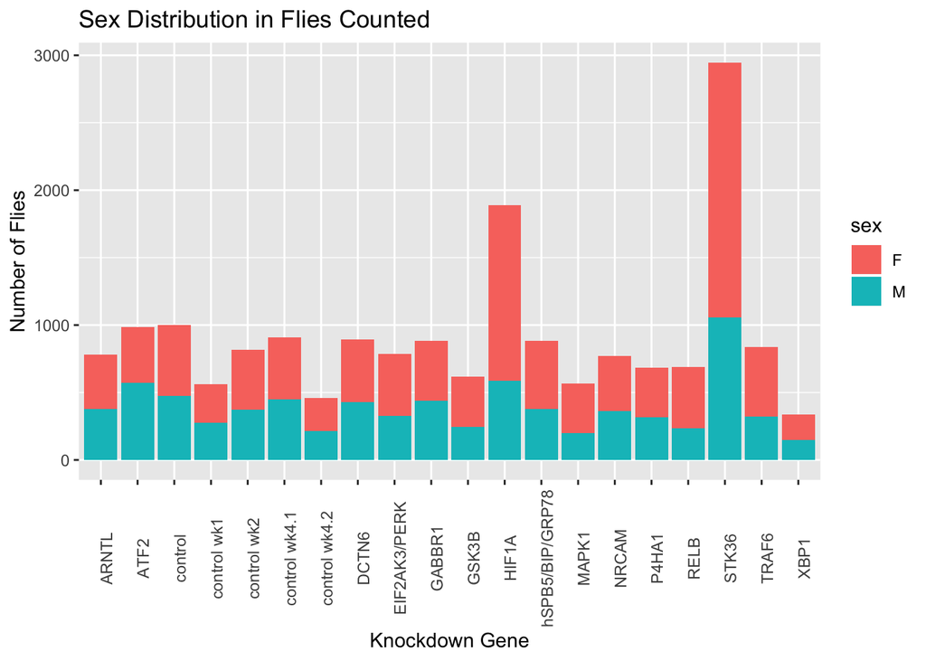

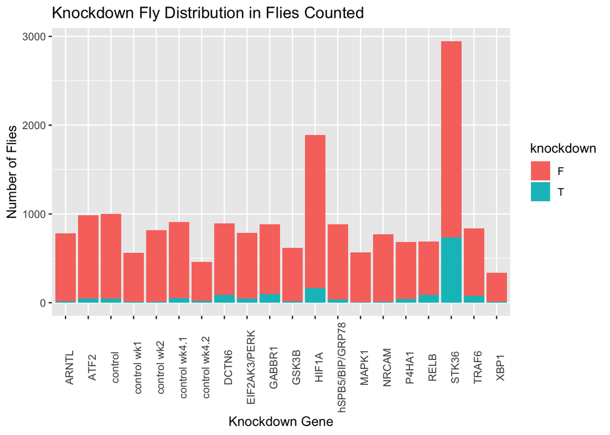

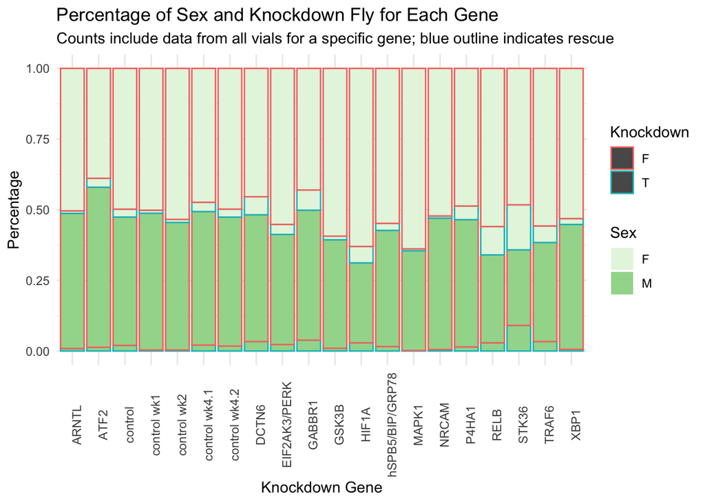

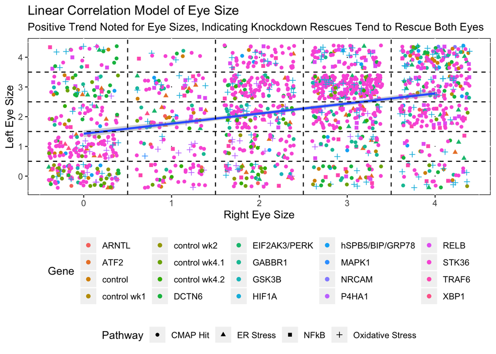